# Proyecto 2

Rodrigo Mansilla, Javier Chen

2025-02-25

# Introducción

# Carga y Preprocesamiento de Datos

## Carga de datos

```r
# Cargar datos preprocesados (los mismos usados para regresión lineal)
train_data <- read.csv("C:/Users/rodri/Documents/Data-Mining/DM-Proyecto-2/data/processed/train_preprocessed.csv", stringsAsFactors = TRUE)
test_data  <- read.csv("C:/Users/rodri/Documents/Data-Mining/DM-Proyecto-2/data/processed/test_preprocessed.csv", stringsAsFactors = TRUE)

cat("Dimensiones originales de train:", dim(train_data), "\n")
```

```
## Dimensiones originales de train: 1169 84
```

```r
cat("Dimensiones originales de test:", dim(test_data), "\n")
```

```
## Dimensiones originales de test: 291 84
```

```r
# Para asegurar consistencia: ajustar niveles de variables categóricas problemáticas
test_data$Condition2 <- factor(test_data$Condition2, levels = levels(train_data$Condition2))
test_data$RoofMatl   <- factor(test_data$RoofMatl,   levels = levels(train_data$RoofMatl))

# ----------------------------
# Paso 1.1. Filtrar únicamente filas completas (sin NA)
# ----------------------------
train_data <- train_data[complete.cases(train_data), ]
test_data  <- test_data[complete.cases(test_data), ]
cat("Dimensiones de train (sin NA):", dim(train_data), "\n")
```

```
## Dimensiones de train (sin NA): 1098 84
```

```r
cat("Dimensiones de test (sin NA):", dim(test_data), "\n")
```

```
## Dimensiones de test (sin NA): 269 84
```

```r
# ----------------------------
# Paso 3. Preprocesamiento extra: ajustar niveles y escalar variables
# ----------------------------
# Ajustar niveles de variables categóricas en el conjunto de prueba para que coincidan con el de entrenamiento
factor_vars <- names(train_data)[sapply(train_data, is.factor)]
for (var in factor_vars) {
  if (var %in% names(test_data)) {
    test_data[[var]] <- factor(test_data[[var]], levels = levels(train_data[[var]]))
  }
}
```

## Árboles de Decisión

### Árbol de regresión parametrizado por defecto

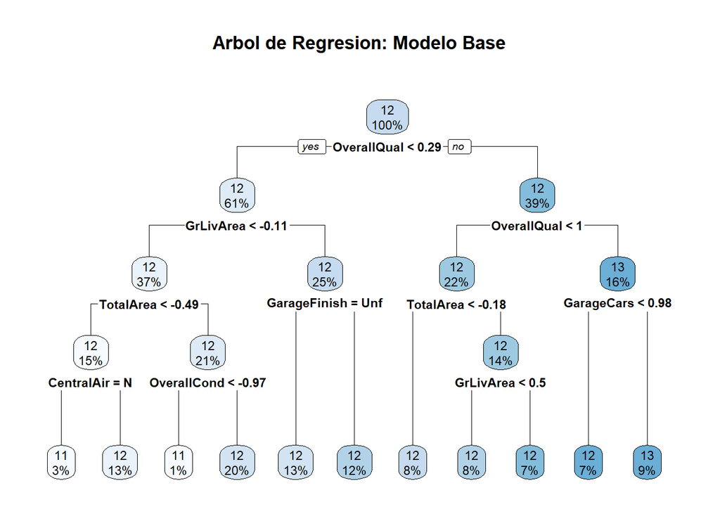

### Predicción con el modelo de árbol base

#### Datos de Prueba

```
## RMSE del Árbol de Regresión (Modelo Base): 0.2004715
```

```
## MSE del Árbol de Regresión (Modelo Base): 0.04018882
```

Estos valores son los errores cuadráticos medios y las raíces de los errores cuadráticos medios para el modelo de árbol de regresión con parámetros por defecto.

```
## RMSE en entrenamiento (Modelo Base): 0.1814265
```

```
## MSE en entrenamiento (Modelo Base): 0.03291556
```

#### Grafico de Predicciones vs Real

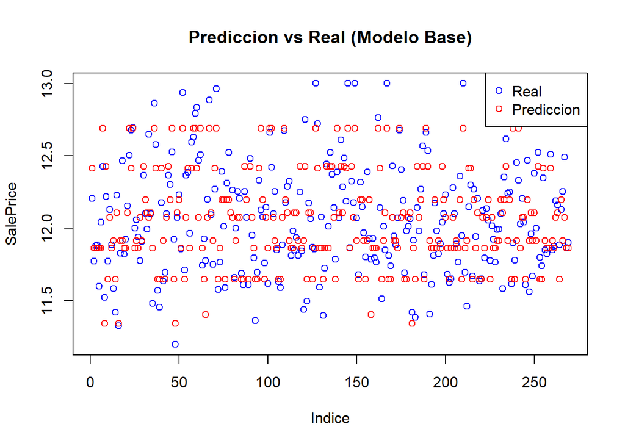

### Árbol de Regresión Tuned

### Modelos de Validación Cruzada

```
## CART
##
## 1098 samples
##   83 predictor
##
## No pre-processing
## Resampling: Cross-Validated (15 fold)
## Summary of sample sizes: 1025, 1025, 1025, 1024, 1024, 1024, ...
## Resampling results across tuning parameters:
##
##   cp          RMSE       Rsquared   MAE
##   0.07544763  0.2418103  0.5859931  0.1850073
##   0.08852679  0.2660731  0.4954075  0.2038175
##   0.46600128  0.3338730  0.4089523  0.2612193
##
## RMSE was used to select the optimal model using the smallest value.
## The final value used for the model was cp = 0.07544763.
```

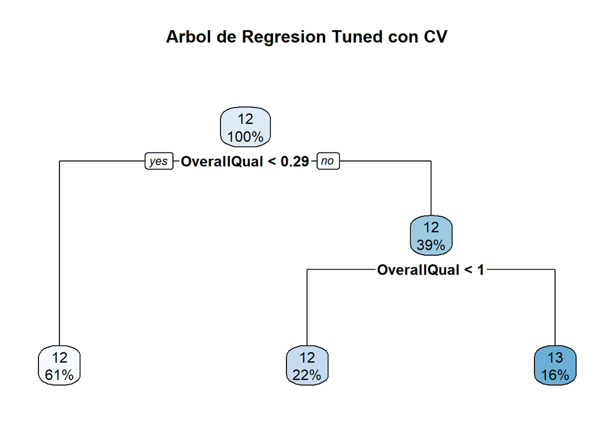

### Predicciones y Evaluación

#### Datos de Prueba

```
## RMSE del Arbol de Regresion (Modelo CV): 0.4497077
```

#### Datos de entrenamiento

```
## RMSE en entrenamiento (Modelo CV): 0.2498088
```

El modelo con validacion cruzada parece hacerlo peor.

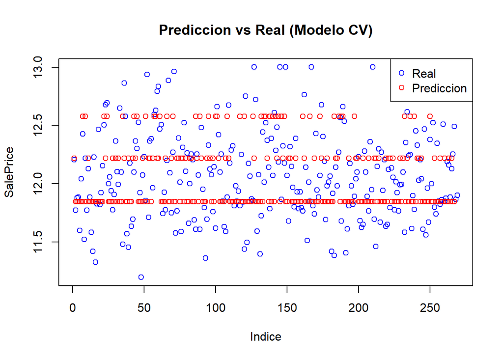

### Árbol de Regresión con diferentes profundidades

|  | model | parameter | label | forReg | forClass | probModel |
| --- | --- | --- | --- | --- | --- | --- |
| 1 | rpart | cp | Complexity Parameter | TRUE | TRUE | TRUE |

|  | model | parameter | label | forReg | forClass | probModel |
| --- | --- | --- | --- | --- | --- | --- |
| 1 | rpart2 | maxdepth | Max Tree Depth | TRUE | TRUE | TRUE |

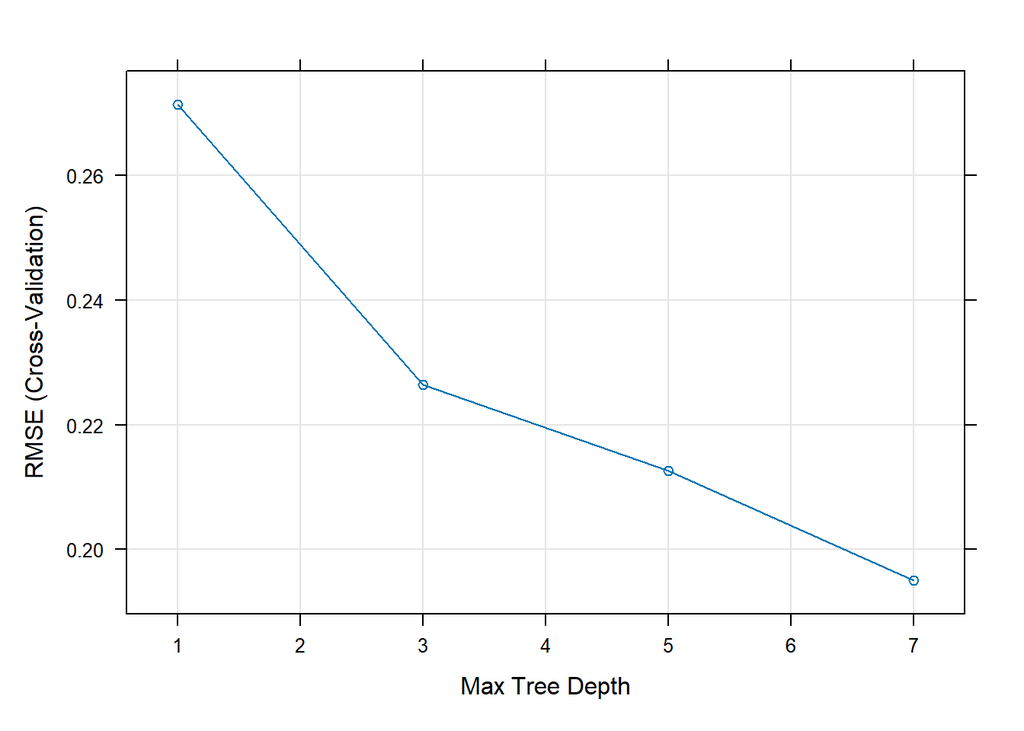

### Modelo Greedy

#### Datos de Prueba

```
## RMSE del Arbol de Regresion (Modelo maxdepth = 3): 0.4668335
```

```
## MSE del Arbol de Regresion (Modelo maxdepth = 3): 0.2179336
```

#### Datos de entrenamiento

[output not shown]

[output not shown]

#### Grafico de Predicciones vs Real

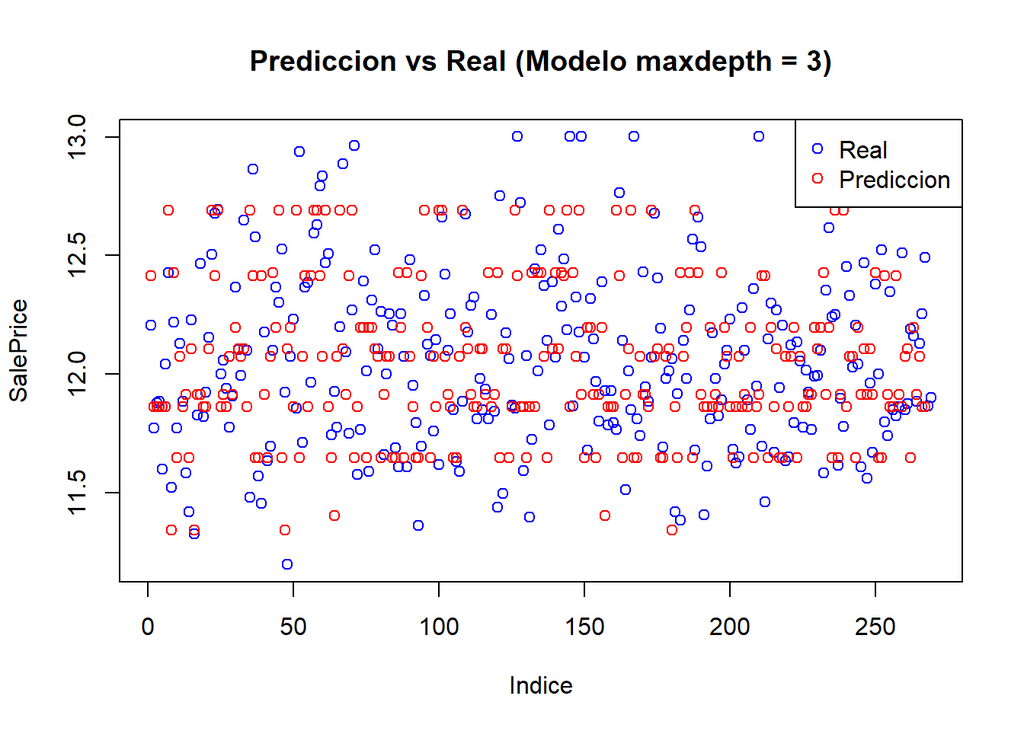

### Comparación de Modelos

```
##         Modelo Base           Modelo CV Modelo maxdepth = 3
##           0.2004715           0.4497077           0.4668335
```

## Comparación con modelos Lineales

### Modelo Lineal Múltiple normalizado

Resumen del Modelo Lineal Múltiple (Normalizado)

| term | estimate | std.error | statistic | p.value |
| --- | --- | --- | --- | --- |
| (Intercept) | 0.0000000 | 0.0097279 | 0.0000000 | 1.0000000 |
| Id | -0.0023964 | 0.0099049 | -0.2419447 | 0.8088698 |
| MSSubClass | -0.0110375 | 0.0137708 | -0.8015159 | 0.4230127 |
| LotFrontage | -0.0020948 | 0.0108590 | -0.1929065 | 0.8470691 |
| LotArea | 0.1065800 | 0.0139735 | 7.6273149 | 0.0000000 |
| OverallQual | 0.2633257 | 0.0173703 | 15.1595517 | 0.0000000 |
| OverallCond | 0.1527835 | 0.0125226 | 12.2005950 | 0.0000000 |
| YearBuilt | 0.2277788 | 0.0233017 | 9.7752222 | 0.0000000 |
| YearRemodAdd | 0.0559511 | 0.0156978 | 3.5642536 | 0.0003811 |
| MasVnrArea | 0.0081431 | 0.0117298 | 0.6942235 | 0.4876941 |
| BsmtFinSF1 | -0.3862725 | 0.0488090 | -7.9139606 | 0.0000000 |
| BsmtFinSF2 | -0.1635762 | 0.0211091 | -7.7490828 | 0.0000000 |
| BsmtUnfSF | -0.4597327 | 0.0483869 | -9.5011843 | 0.0000000 |
| TotalBsmtSF | 0.5305840 | 0.0454556 | 11.6725820 | 0.0000000 |
| X1stFlrSF | 0.0753084 | 0.0419913 | 1.7934285 | 0.0731894 |
| X2ndFlrSF | 0.0952970 | 0.0436114 | 2.1851416 | 0.0290968 |
| LowQualFinSF | 0.0015971 | 0.0107489 | 0.1485806 | 0.8819128 |
| GrLivArea | 0.2282112 | 0.0478018 | 4.7741095 | 0.0000021 |
| BsmtFullBath | 0.0300693 | 0.0148472 | 2.0252474 | 0.0430922 |
| BsmtHalfBath | -0.0065905 | 0.0105232 | -0.6262831 | 0.5312641 |
| FullBath | 0.0140834 | 0.0172048 | 0.8185740 | 0.4132135 |
| HalfBath | -0.0060571 | 0.0149598 | -0.4048927 | 0.6856381 |
| BedroomAbvGr | -0.0492337 | 0.0151064 | -3.2591249 | 0.0011531 |
| KitchenAbvGr | -0.0600559 | 0.0121278 | -4.9518994 | 0.0000009 |
| TotRmsAbvGrd | 0.0461142 | 0.0213240 | 2.1625472 | 0.0307991 |
| Fireplaces | 0.0535086 | 0.0124019 | 4.3145554 | 0.0000175 |
| GarageYrBlt | 0.0253649 | 0.0207557 | 1.2220696 | 0.2219530 |
| GarageCars | 0.0626820 | 0.0199542 | 3.1412935 | 0.0017286 |
| GarageArea | 0.0309476 | 0.0202377 | 1.5292061 | 0.1265117 |
| WoodDeckSF | 0.0192829 | 0.0109773 | 1.7566179 | 0.0792717 |
| OpenPorchSF | 0.0220063 | 0.0109253 | 2.0142464 | 0.0442359 |
| EnclosedPorch | 0.0200894 | 0.0112063 | 1.7926942 | 0.0733069 |
| X3SsnPorch | 0.0057912 | 0.0099568 | 0.5816315 | 0.5609386 |
| ScreenPorch | 0.0199467 | 0.0104894 | 1.9016039 | 0.0574939 |
| PoolArea | 0.0007308 | 0.0105781 | 0.0690890 | 0.9449318 |
| MiscVal | -0.0158895 | 0.0101422 | -1.5666686 | 0.1174906 |
| MoSold | 0.0004856 | 0.0100831 | 0.0481626 | 0.9615958 |
| YrSold | -0.0300214 | 0.0100580 | -2.9848196 | 0.0029025 |
| TotalArea | NA | NA | NA | NA |
| HouseAge | NA | NA | NA | NA |
| TotalBath | NA | NA | NA | NA |

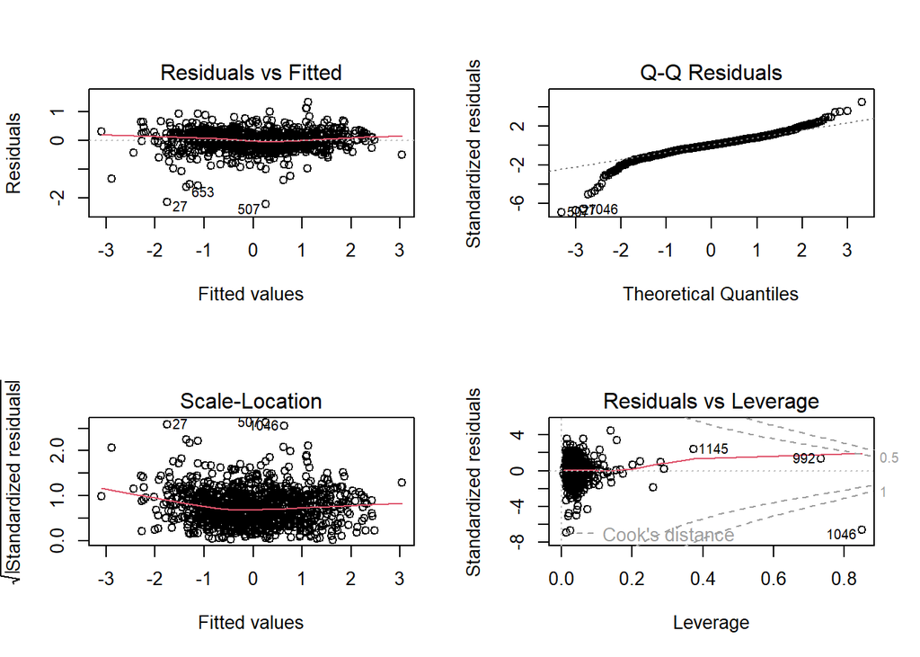

Seleccionamos predictores

Resumen del Modelo Multivariado (Stepwise Backward)

| term | estimate | std.error | statistic | p.value |
| --- | --- | --- | --- | --- |
| (Intercept) | 12.0206630 | 0.0037427 | 3211.751594 | 0.0000000 |
| LotArea | 0.0410784 | 0.0045243 | 9.079562 | 0.0000000 |
| OverallQual | 0.1034028 | 0.0065992 | 15.669025 | 0.0000000 |
| OverallCond | 0.0586203 | 0.0047924 | 12.231922 | 0.0000000 |
| YearBuilt | 0.0946679 | 0.0069378 | 13.645188 | 0.0000000 |
| YearRemodAdd | 0.0232040 | 0.0056344 | 4.118277 | 0.0000411 |
| BsmtFinSF1 | -0.1450174 | 0.0172061 | -8.428262 | 0.0000000 |
| BsmtFinSF2 | -0.0582652 | 0.0070409 | -8.275197 | 0.0000000 |
| BsmtUnfSF | -0.1724466 | 0.0171976 | -10.027346 | 0.0000000 |
| TotalBsmtSF | 0.2010312 | 0.0161376 | 12.457322 | 0.0000000 |
| X1stFlrSF | 0.0307535 | 0.0149176 | 2.061553 | 0.0394910 |
| X2ndFlrSF | 0.0347574 | 0.0152115 | 2.284939 | 0.0225111 |
| GrLivArea | 0.0902281 | 0.0174851 | 5.160275 | 0.0000003 |
| BsmtFullBath | 0.0107470 | 0.0051947 | 2.068835 | 0.0388009 |
| BedroomAbvGr | -0.0180859 | 0.0056140 | -3.221558 | 0.0013133 |
| KitchenAbvGr | -0.0263457 | 0.0047208 | -5.580748 | 0.0000000 |
| TotRmsAbvGrd | 0.0188853 | 0.0081027 | 2.330744 | 0.0199516 |
| Fireplaces | 0.0193676 | 0.0046026 | 4.207993 | 0.0000279 |
| GarageCars | 0.0276235 | 0.0087184 | 3.168422 | 0.0015760 |
| GarageArea | 0.0174880 | 0.0082441 | 2.121268 | 0.0341282 |
| WoodDeckSF | 0.0073060 | 0.0039430 | 1.852893 | 0.0641724 |
| OpenPorchSF | 0.0086565 | 0.0041970 | 2.062537 | 0.0393972 |
| EnclosedPorch | 0.0078568 | 0.0042670 | 1.841306 | 0.0658530 |
| ScreenPorch | 0.0069579 | 0.0038610 | 1.802102 | 0.0718103 |
| MiscVal | -0.0094589 | 0.0062785 | -1.506548 | 0.1322211 |
| YrSold | -0.0108687 | 0.0036785 | -2.954683 | 0.0031983 |

### Test de Normalidad

```
##
##  Lilliefors (Kolmogorov-Smirnov) normality test
##
## data:  modelo_mult2$residuals
## D = 0.080489, p-value < 2.2e-16
```

### Predicción y Ecualización

MSE y RMSE del Modelo Stepwise Backward en Entrenamiento y Prueba

| Conjunto | MSE | RMSE |
| --- | --- | --- |
| Entrenamiento | 0.0141304 | 0.1188715 |
| Prueba | 0.0166454 | 0.1290171 |

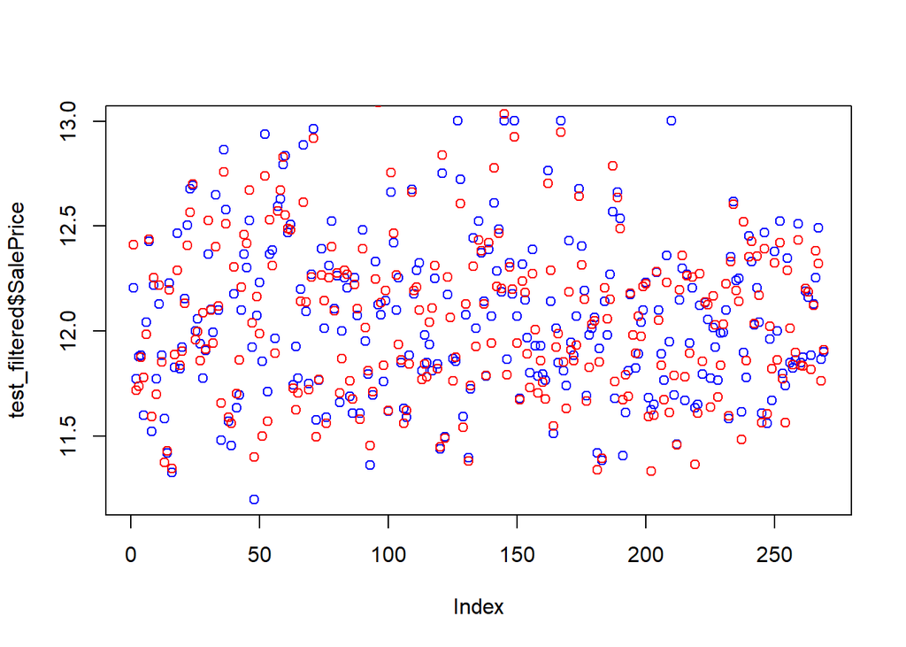

Previamente se obtuvo el modelo lineal normalizado el cual tuvo el rendimiento mas adecuado para el proyecto. Para el cual se encontraron los siguientes halazgos>

- **Principales Hallazgos en los Coeficientes:**
  - Variables como *OverallQual*, *OverallCond*, *YearBuilt*, *LotArea* y *TotalBsmtSF* muestran coeficientes positivos y muy significativos.
  - Muchas otras variables presentan p-valores altos, sugiriendo que su aporte es menor o está solapado por predictores más fuertes.
- **Residuos y Ajuste del Modelo:**
  - Los gráficos de diagnóstico (Residuals vs Fitted, Q-Q) revelan patrones y desviaciones en las colas, indicando no normalidad de residuos.
  - El test de Lilliefors confirma p-valor cercano a 0, por lo que se rechaza la hipótesis de normalidad.
  - La alta dimensionalidad y varias variables con poca significancia sugieren posible sobreajuste.

## Variable Respuesta

A partir de la variable SalePrice, podemos proponer:

Económicas: casas con SalePrice < 130,000 (aprox. primer cuartil) Intermedias: casas con SalePrice >= 130,000 y < 215,000 (entre el primer y el tercer cuartil) Caras: casas con SalePrice >= 215,000 (por encima del tercer cuartil)

```
##
## Umbrales elegidos para clasificar:
```

```
## Económicas: <  11.80904
```

```
## Intermedias: [ 11.80904 ,  12.29739 )
```

```
## Caras: >=  12.29739
```

```
## Distribución de PriceCat en train:
```

```
##
##  Economicas Intermedias       Caras
##         275         548         275
```

```
##
## Distribución de PriceCat en test:
```

```
##
##  Economicas Intermedias       Caras
##          71         131          67
```

### Árbol de Clasificación para PriceCat

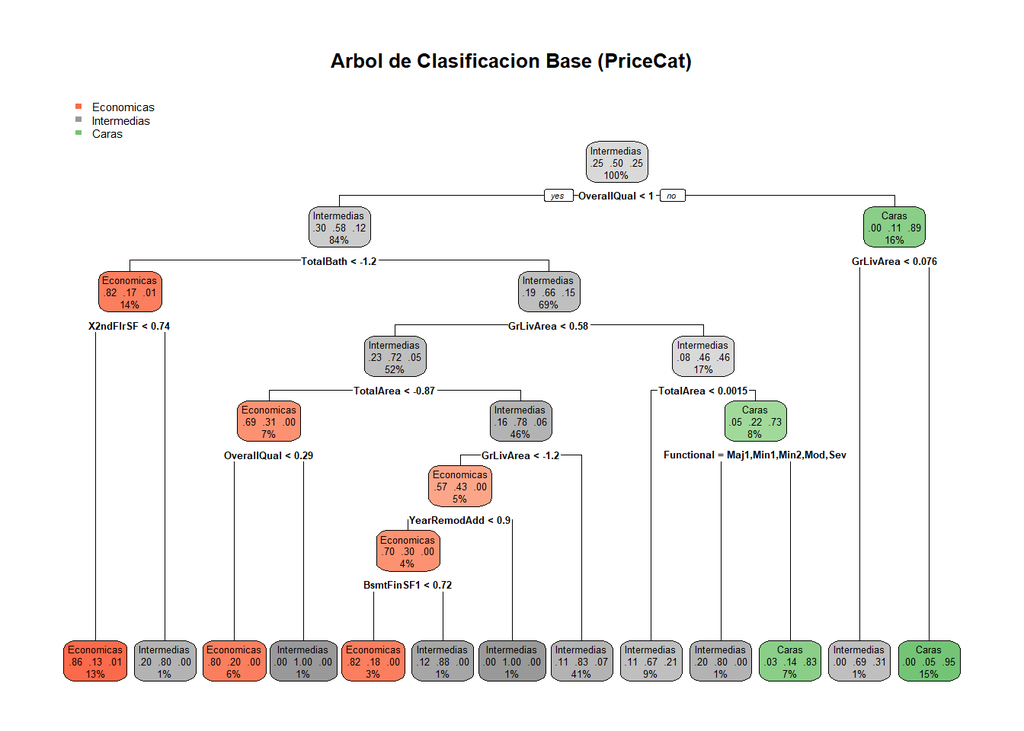

### Metricas de Evaluación

```
## Matriz de Confusión - Árbol de Clasificación (Modelo Base):
```

```
## Confusion Matrix and Statistics
##
##              Reference
## Prediction    Economicas Intermedias Caras
##   Economicas          42          17     0
##   Intermedias         29         104    20
##   Caras                0          10    47
##
## Overall Statistics
##
##                Accuracy : 0.7175
##                  95% CI : (0.6596, 0.7705)
##     No Information Rate : 0.487
##     P-Value [Acc > NIR] : 1.384e-14
##
##                   Kappa : 0.5386
##
##  Mcnemar's Test P-Value : NA
##
## Statistics by Class:
##
##                      Class: Economicas Class: Intermedias Class: Caras
## Sensitivity                     0.5915             0.7939       0.7015
## Specificity                     0.9141             0.6449       0.9505
## Pos Pred Value                  0.7119             0.6797       0.8246
## Neg Pred Value                  0.8619             0.7672       0.9057
## Prevalence                      0.2639             0.4870       0.2491
## Detection Rate                  0.1561             0.3866       0.1747
## Detection Prevalence            0.2193             0.5688       0.2119
## Balanced Accuracy               0.7528             0.7194       0.8260
```

El árbol de clasificación tiene una precisión global del 71.75%, por lo que clasifica relativamente bien las casas en la categoría Caras (alta especificidad y buen valor predictivo) y en Intermedias, aunque la sensibilidad para Económicas es algo menor. Esto sugiere que, si bien el modelo es razonable, puede haber margen de mejora en distinguir las casas económicas, donde se cometen más errores.